# HW 4

Yusuf Uzhunnan

12/2/2020

```r
library(dplyr)
```

```r
library("ggplot2")
library(stringr)

# Include leaflet for map
library(leaflet)
```

### Read File

```r
rentalData <- read.csv("AB_NYC_2019.csv")
```

### Data Cleanup

```r
str(rentalData)
```

```
## 'data.frame':    48895 obs. of  16 variables:
##  $ id                            : int  2539 2595 3647 3831 5022 5099 5121 5178 5203 5238 ...
##  $ name                          : chr  "Clean & quiet apt home by the park" "Skylit Midtown Castle" "THE VILLAGE OF HARLEM....NEW YORK !" "Cozy Entire Floor of Brownstone" ...
##  $ host_id                       : int  2787 2845 4632 4869 7192 7322 7356 8967 7490 7549 ...
##  $ host_name                     : chr  "John" "Jennifer" "Elisabeth" "LisaRoxanne" ...
##  $ neighbourhood_group           : chr  "Brooklyn" "Manhattan" "Manhattan" "Brooklyn" ...
##  $ neighbourhood                 : chr  "Kensington" "Midtown" "Harlem" "Clinton Hill" ...
##  $ latitude                      : num  40.6 40.8 40.8 40.7 40.8 ...
##  $ longitude                     : num  -74 -74 -73.9 -74 -73.9 ...
##  $ room_type                     : chr  "Private room" "Entire home/apt" "Private room" "Entire home/apt" ...
##  $ price                         : int  149 225 150 89 80 200 60 79 79 150 ...
##  $ minimum_nights                : int  1 1 3 1 10 3 45 2 2 1 ...
##  $ number_of_reviews             : int  9 45 0 270 9 74 49 430 118 160 ...
##  $ last_review                   : chr  "2018-10-19" "2019-05-21" "" "2019-07-05" ...
##  $ reviews_per_month             : num  0.21 0.38 NA 4.64 0.1 0.59 0.4 3.47 0.99 1.33 ...
##  $ calculated_host_listings_count: int  6 2 1 1 1 1 1 1 1 4 ...
##  $ availability_365              : int  365 355 365 194 0 129 0 220 0 188 ...
```

```r
summary(rentalData)
```

```
##        id               name              host_id           host_name
##  Min.   :    2539   Length:48895       Min.   :     2438   Length:48895
##  1st Qu.: 9471945   Class :character   1st Qu.:  7822033   Class :character
##  Median :19677284   Mode  :character   Median : 30793816   Mode  :character
##  Mean   :19017143                      Mean   : 67620011
##  3rd Qu.:29152178                      3rd Qu.:107434423
##  Max.   :36487245                      Max.   :274321313
##
##  neighbourhood_group neighbourhood         latitude       longitude
##  Length:48895        Length:48895       Min.   :40.50   Min.   :-74.24
##  Class :character    Class :character   1st Qu.:40.69   1st Qu.:-73.98
##  Mode  :character    Mode  :character   Median :40.72   Median :-73.96
##                                         Mean   :40.73   Mean   :-73.95
##                                         3rd Qu.:40.76   3rd Qu.:-73.94
##                                         Max.   :40.91   Max.   :-73.71
##
##   room_type             price         minimum_nights    number_of_reviews
##  Length:48895       Min.   :    0.0   Min.   :   1.00   Min.   :  0.00
##  Class :character   1st Qu.:   69.0   1st Qu.:   1.00   1st Qu.:  1.00
##  Mode  :character   Median :  106.0   Median :   3.00   Median :  5.00
##                     Mean   :  152.7   Mean   :   7.03   Mean   : 23.27
##                     3rd Qu.:  175.0   3rd Qu.:   5.00   3rd Qu.: 24.00
##                     Max.   :10000.0   Max.   :1250.00   Max.   :629.00
##
##  last_review        reviews_per_month calculated_host_listings_count
##  Length:48895       Min.   : 0.010    Min.   :  1.000
##  Class :character   1st Qu.: 0.190    1st Qu.:  1.000
##  Mode  :character   Median : 0.720    Median :  1.000
##                     Mean   : 1.373    Mean   :  7.144
##                     3rd Qu.: 2.020    3rd Qu.:  2.000
##                     Max.   :58.500    Max.   :327.000
##                     NA's   :10052
##  availability_365
##  Min.   :  0.0
##  1st Qu.:  0.0
##  Median : 45.0
##  Mean   :112.8
##  3rd Qu.:227.0
##  Max.   :365.0
##
```

```r
head(rentalData)
```

```
##     id                                             name host_id   host_name
## 1 2539               Clean & quiet apt home by the park    2787        John
## 2 2595                            Skylit Midtown Castle    2845    Jennifer
## 3 3647              THE VILLAGE OF HARLEM....NEW YORK !    4632   Elisabeth
## 4 3831                  Cozy Entire Floor of Brownstone    4869 LisaRoxanne
## 5 5022 Entire Apt: Spacious Studio/Loft by central park    7192       Laura
## 6 5099        Large Cozy 1 BR Apartment In Midtown East    7322       Chris
##   neighbourhood_group neighbourhood latitude longitude       room_type price
## 1            Brooklyn    Kensington 40.64749 -73.97237    Private room   149
## 2           Manhattan       Midtown 40.75362 -73.98377 Entire home/apt   225
## 3           Manhattan        Harlem 40.80902 -73.94190    Private room   150
## 4            Brooklyn  Clinton Hill 40.68514 -73.95976 Entire home/apt    89
## 5           Manhattan   East Harlem 40.79851 -73.94399 Entire home/apt    80
## 6           Manhattan   Murray Hill 40.74767 -73.97500 Entire home/apt   200
##   minimum_nights number_of_reviews last_review reviews_per_month
## 1              1                 9  2018-10-19              0.21
## 2              1                45  2019-05-21              0.38
## 3              3                 0                            NA
## 4              1               270  2019-07-05              4.64
## 5             10                 9  2018-11-19              0.10
## 6              3                74  2019-06-22              0.59
##   calculated_host_listings_count availability_365
## 1                              6              365
## 2                              2              355
## 3                              1              365
## 4                              1              194
## 5                              1                0
## 6                              1              129
```

```r
tail(rentalData)
```

```
##             id                                              name   host_id
## 48890 36484363                                QUIT PRIVATE HOUSE 107716952
## 48891 36484665   Charming one bedroom - newly renovated rowhouse   8232441
## 48892 36485057     Affordable room in Bushwick/East Williamsburg   6570630
## 48893 36485431           Sunny Studio at Historical Neighborhood  23492952
## 48894 36485609              43rd St. Time Square-cozy single bed  30985759
## 48895 36487245 Trendy duplex in the very heart of Hell's Kitchen  68119814
##           host_name neighbourhood_group      neighbourhood latitude longitude
## 48890       Michael              Queens            Jamaica 40.69137 -73.80844
## 48891       Sabrina            Brooklyn Bedford-Stuyvesant 40.67853 -73.94995
## 48892       Marisol            Brooklyn           Bushwick 40.70184 -73.93317
## 48893 Ilgar & Aysel           Manhattan             Harlem 40.81475 -73.94867
## 48894           Taz           Manhattan     Hell's Kitchen 40.75751 -73.99112
## 48895    Christophe           Manhattan     Hell's Kitchen 40.76404 -73.98933
##             room_type price minimum_nights number_of_reviews last_review
## 48890    Private room    65              1                 0
## 48891    Private room    70              2                 0
## 48892    Private room    40              4                 0
## 48893 Entire home/apt   115             10                 0
## 48894     Shared room    55              1                 0
## 48895    Private room    90              7                 0
##       reviews_per_month calculated_host_listings_count availability_365
## 48890                NA                              2              163
## 48891                NA                              2                9
## 48892                NA                              2               36
## 48893                NA                              1               27
## 48894                NA                              6                2
## 48895                NA                              1               23
```

```r
# Change IDs to factors
rentalData$id <- as.factor(rentalData$id)
rentalData$host_id <- as.factor(rentalData$host_id)
```

## Interesting Metrics

### How do Rental Rates differ between boroughs?

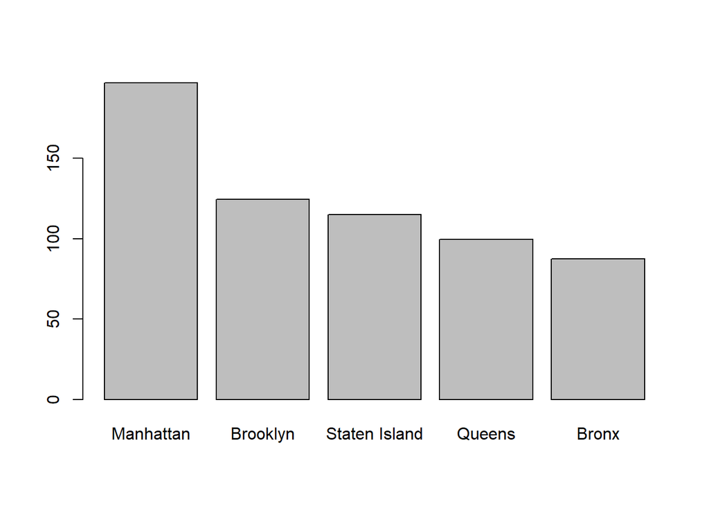

```r
avgBoroughRates <- tapply(rentalData$price,rentalData$neighbourhood_group,mean, na.rm = TRUE)
priceByBoroughSorted <- barplot(sort(avgBoroughRates, decreasing = TRUE))
```

```r
priceByBoroughSorted
```

```
##      [,1]
## [1,]  0.7
## [2,]  1.9
## [3,]  3.1
## [4,]  4.3
## [5,]  5.5
```

Takeaways: From the graph, we can see that Manhattan has the most expensive rentals on average, which was expected. On the other hand, the Bronx tends to have the lowest rates on average.

### Does the Year of the most recent review have an impact on price?

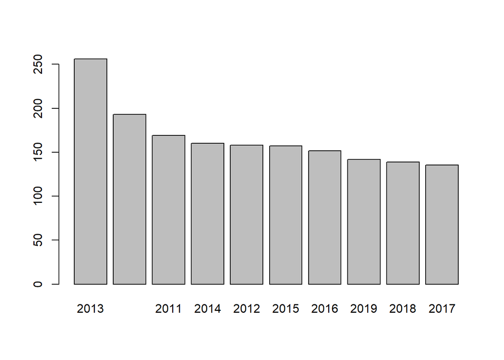

```r
# Add new column with year of last review
rentalData$recentReviewYear <- substr(rentalData$last_review,1,4)

# Take the average price for each year of the most recent review
ratesByLastReview <- tapply(rentalData$price,rentalData$recentReviewYear,mean, na.rm = TRUE)

# Plot Barplot
priceByLastReviewSorted <- barplot(sort(ratesByLastReview, decreasing = TRUE))
```

```r
priceByLastReviewSorted
```

```
##       [,1]
##  [1,]  0.7
##  [2,]  1.9
##  [3,]  3.1
##  [4,]  4.3
##  [5,]  5.5
##  [6,]  6.7
##  [7,]  7.9
##  [8,]  9.1
##  [9,] 10.3
## [10,] 11.5
```

By looking at the graph above, we can see that while most of the average prices are at similar levels, the rentals with earlier years for their last review tend to have higher prices in general. This may be because less people stay in more expensive rentals, which makes it likely that the pricier rentals have not had a review in a while.

### How does the frequency of reviews per month affect the rental price?

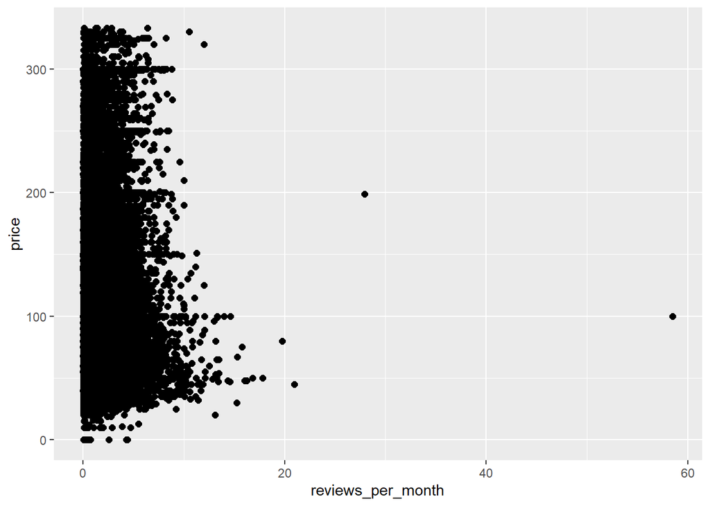

```r
# Find and Remove Outliers
Q <- quantile(rentalData$price, probs=c(.25, .75), na.rm = FALSE)
iqr <- IQR(rentalData$price)
upperEnd <-  Q[2]+1.5*iqr
lowerEnd<- Q[1]-1.5*iqr

noOutliersData <- rentalData[rentalData$price > lowerEnd & rentalData$price < upperEnd, ]

# Graph Scatter Plot
reviewFreqVsPrice <- ggplot(data=noOutliersData, aes(x=reviews_per_month, y=price)) + geom_point(size=2, alpha=1)
reviewFreqVsPrice
```

Overall, lower frequency seems to be related to slightlyhigher rates. This is potentially for the same reason mentioned in the previous question, where pricier rentals are less common, meaning less reviews.

### What is the distribution of rental prices for each of the different room types in NYC?

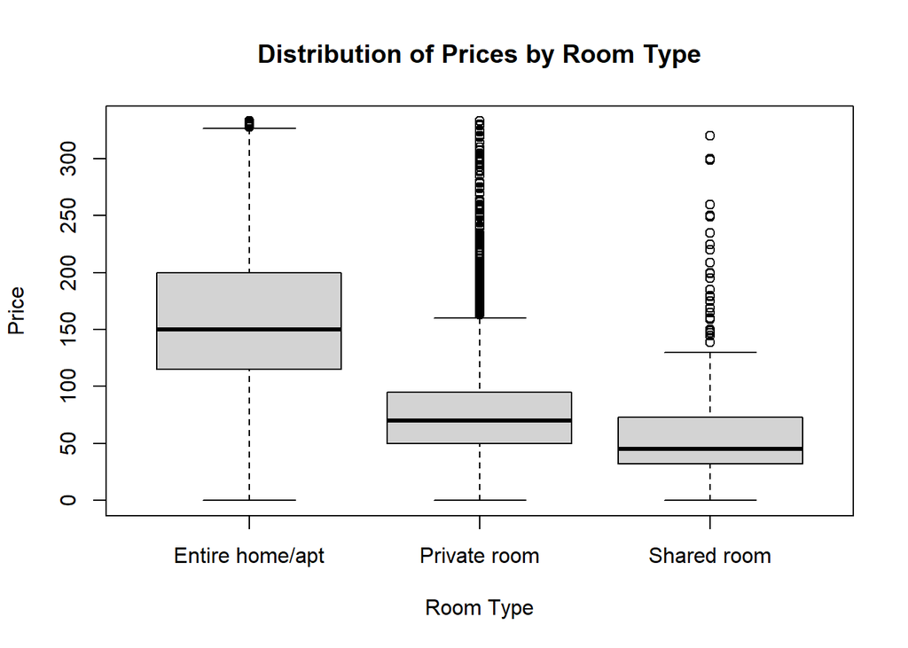

```r
# Graph Box Plots For Each Room Type, Using data w/out outliers
boxplot(price~room_type,data=noOutliersData, main="Distribution of Prices by Room Type", xlab="Room Type", ylab="Price")
```

We see from these plots that entire homes/apts are significantly more expensive, but also have much more of a spread in terms of prices compared to the other room types. This makes sense as an entire apartment can range from a studio to a whole house.

## Map Based Visualizations

### Where are the 100 most expensive rentals?

```r
#Create new Data Frame with Top 100 most expensive rentals
rentalsSortedByPrice <- rentalData[order(-rentalData$price), ]
hundredMostExpensive <- head(rentalsSortedByPrice, 100)

# Map new dataframe with leaflet
m1 <- leaflet()
m1 <- addTiles(m1)
m1 <- addMarkers(m1, lng=hundredMostExpensive$longitude, lat=hundredMostExpensive$latitude, popup="100 Most Expensive Rentals")
m1
```

[interactive chart not shown]

By looking at the map above, we can see that although there are markers in various parts of New York, the vast majority of the 100 most expensive are located in the Manhattan area.

### Where are the rentals owned by the host with the most listings?

```r
# create new data frame with qualified listings
frequentHostRentals <- rentalData[rentalData$calculated_host_listings_count == max(rentalData$calculated_host_listings_count), ]

# Map new Data Frame
m2 <- leaflet()
m2 <- addTiles(m2)
m2 <- addMarkers(m2, lng=frequentHostRentals$longitude, lat=frequentHostRentals$latitude, popup="Rentals owned by the host with the most listings")
m2
```

[interactive chart not shown]

From this map we can see that the host with the most listings has most of their listings around either the Financial District or Midtown in Manhattan. This makes sense because a wealthier landlord with many properties may be mostly focused on the nicer areas of Manhattan

## Impact of Description on price

### How does the length of the description affect price?

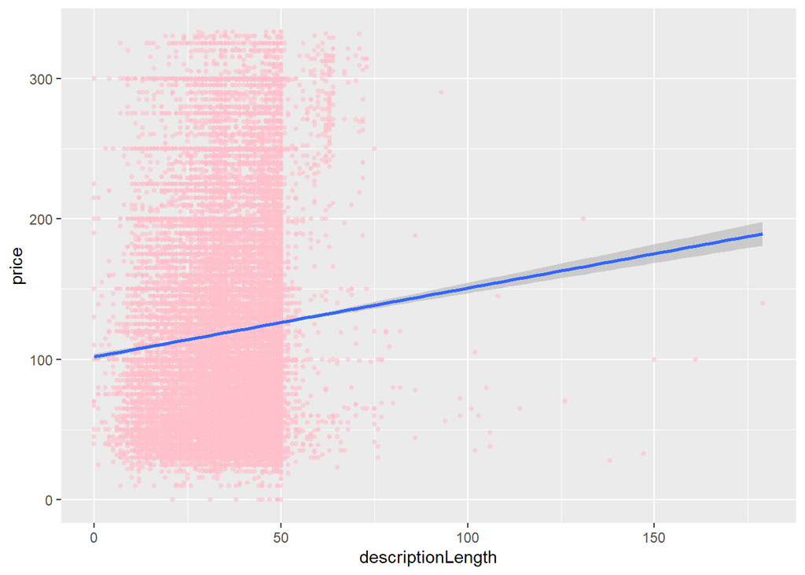

```r
# Use data w/out outliers and create new column with decription length
noOutliersData$descriptionLength <- nchar(as.character(noOutliersData$name))

# Graph Scatter Plot
descriptionLengthVsPrice <- ggplot(data=noOutliersData, aes(x=descriptionLength, y=price)) + geom_point(size=1, alpha=.6, colour="pink") + geom_smooth(method = "lm")
descriptionLengthVsPrice
```

While the data is very spread out, it seems that rentals with longer descriptions are usually more likely to have higher prices. This could be because customers are usually more willing to pay more for something when they have a better idea of what they are getting for their money.

## Other Insights

### What room type is most expensive on average?

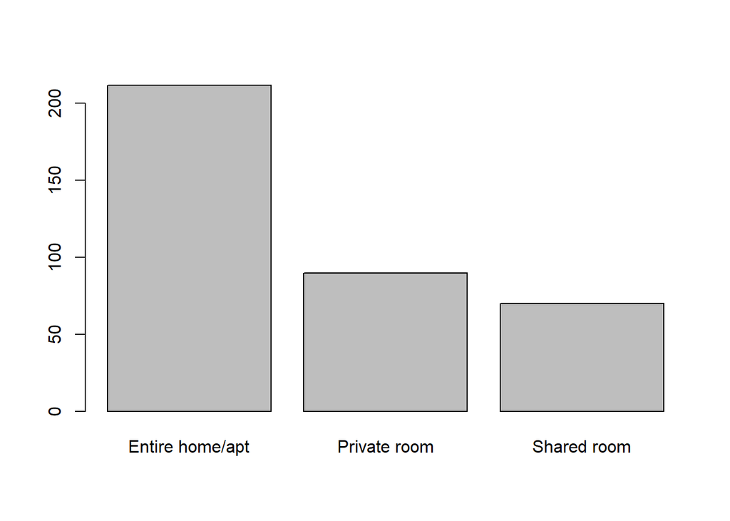

```r
# Take the average price for each room type
ratesByRoomType <- tapply(rentalData$price,rentalData$room_type,mean, na.rm = TRUE)

# Plot Barplot
priceByRoomTypeSorted <- barplot(sort(ratesByRoomType, decreasing = TRUE))
```

```r
priceByRoomTypeSorted
```

```
##      [,1]
## [1,]  0.7
## [2,]  1.9
## [3,]  3.1
```

```r
ratesByRoomType
```

```
## Entire home/apt    Private room     Shared room
##       211.79425        89.78097        70.12759
```

From this graph we can see that entire homes are the most expensive on average in NYC at 211.79 dollars, followed by private rooms at 89.78 dollars and Shared rooms at 70.13 dollars.